# Test a Perceptual Phenomenon

### Analyzing the Stroop Effect

In a Stroop task, participants are presented with a list of words, with each word displayed in a color of ink. The participant’s task is to say out loud the color of the ink in which the word is printed. The task has two conditions: a congruent words condition, and an incongruent words condition. In the congruent words condition, the words being displayed are color words whose names match the colors in which they are printed: for example RED, BLUE. In the incongruent words condition, the words displayed are color words whose names do not match the colors in which they are printed: for example PURPLE, ORANGE. In each case, we measure the time it takes to name the ink colors in equally-sized lists. Each participant will go through and record a time from each condition.

**1. What is the independent variable? What is the dependent variable?**

**Dependent variable:** the time it takes to say each work correctly

**Indepedent variable:** the words that change of color to make a point

**2. What is an appropriate set of hypotheses for this task? Specify your null and alternative hypotheses, and clearly define any notation used. Justify your choices.**

The hypotheses test want to prove that the test with incogruent values takes longer than the test with congruent values, so for that reason the H0 and the H1 are set like this:

$$H_0: \mu_{inc} =< \mu_{con} $$

$$H_1: \mu_{inc} > \mu_{con} $$

$\mu_{inc}$ : is the population mean of incongruent values  
$\mu_{con}$: is the population mean of congruent values

In order to reject or accept the null hypothesis, I'll be using a t-test because the data has less than 30 observations and also we don't have the standard deviation from the population.

**3. Report some descriptive statistics regarding this dataset. Include at least one measure of central tendency and at least one measure of variability. The name of the data file is 'stroopdata.csv'.**

```python
import matplotlib.pyplot as plt
import pandas as pd
import numpy as np

stroop = pd.read_csv("stroopdata.csv")
stroop
```

|  | Congruent | Incongruent |
| --- | --- | --- |
| 0 | 12.079 | 19.278 |
| 1 | 16.791 | 18.741 |
| 2 | 9.564 | 21.214 |
| 3 | 8.630 | 15.687 |
| 4 | 14.669 | 22.803 |
| 5 | 12.238 | 20.878 |
| 6 | 14.692 | 24.572 |
| 7 | 8.987 | 17.394 |
| 8 | 9.401 | 20.762 |
| 9 | 14.480 | 26.282 |
| 10 | 22.328 | 24.524 |
| 11 | 15.298 | 18.644 |
| 12 | 15.073 | 17.510 |
| 13 | 16.929 | 20.330 |
| 14 | 18.200 | 35.255 |
| 15 | 12.130 | 22.158 |
| 16 | 18.495 | 25.139 |
| 17 | 10.639 | 20.429 |
| 18 | 11.344 | 17.425 |
| 19 | 12.369 | 34.288 |
| 20 | 12.944 | 23.894 |
| 21 | 14.233 | 17.960 |
| 22 | 19.710 | 22.058 |
| 23 | 16.004 | 21.157 |

```python
#descriptive analytics of the stroop dataset
stroop.describe()
```

|  | Congruent | Incongruent |
| --- | --- | --- |
| count | 24.000000 | 24.000000 |
| mean | 14.051125 | 22.015917 |
| std | 3.559358 | 4.797057 |
| min | 8.630000 | 15.687000 |
| 25% | 11.895250 | 18.716750 |
| 50% | 14.356500 | 21.017500 |
| 75% | 16.200750 | 24.051500 |
| max | 22.328000 | 35.255000 |

```python
#calculation of the median
stroop['Congruent'].median(), stroop['Incongruent'].median()
```

```
(14.3565, 21.0175)
```

We have the next information from the descriptive stadistic:

- **The sample**: 24 observations.
- **The mean:** Congruent= 14.05 - Incongruent = 22.02
- **The median:** Congruent = 14.36 - Incongruent = 21.02
- **The sample standar deviation:** Congruent =3.56 - Incongruent=4.80

**4. Provide one or two visualizations that show the distribution of the sample data. Write one or two sentences noting what you observe about the plot or plots.**

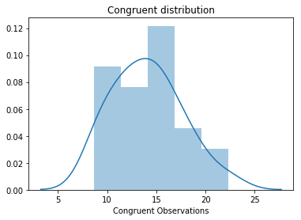

```python
# Build the visualizations here
import seaborn as sns

ax = sns.distplot(stroop['Congruent'])
ax.set_title('Congruent distribution')
ax.set_xlabel('Congruent Observations');
```

This graphic show more or less a normally distributed values, is kinda positively skewed because it has more values gather around the spike that is around 15.

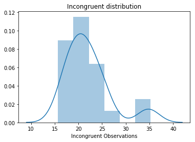

```python
ax = sns.distplot(stroop['Incongruent'])
ax.set_title('Incongruent distribution')
ax.set_xlabel('Incongruent Observations');
```

This graphic also shows a normally distributed values, but in this case there some outliers that could modify the shape of the data, even though, it shows values gather around 20 which indicates that it could follow a normal distribution.

**5. Now, perform the statistical test and report your results. What is your confidence level or Type I error associated with your test? What is your conclusion regarding the hypotheses you set up? Did the results match up with your expectations?**

The confidence level for this test is 95% and the degrees of freedom are 23

```python
stroop['difference']=stroop['Incongruent']-stroop['Congruent']
num = stroop['difference'].sum() / 24
num
```

```
7.9647916666666658
```

```python
stroop['difference_sqr']=(stroop['Congruent']-stroop['Incongruent'])**2
val1_den =stroop['difference_sqr'].sum()
val1_den
```

```
2066.8401910000002
```

```python
den = (val1_den -( stroop['difference'].sum()**2 /24))/ (23*24)
den
```

```
0.98610586948973544
```

```python
import math
t= num / math.sqrt(den)
t
```

```
8.0207069441099552
```

According to the T-Distribution Table, with 23 degrees of freedom and a 95% confidence level we got the t-critical value of **1.714** Our t-statistic is 8.020 which is greater than 1.714, so we **reject the null hypothesis** which means that it takes more time to realize the test with an incongruent value than with a congruent value.

The test, indeed, matches up with my expectations because when I took it, I did more time in the incongruent part.